# Projet ENSAssuRances - Analyse des risques automobiles

Maxendre Bauthamy

16/02/2026

**Contexte** : Ce rapport présente l’analyse technique du portefeuille automobile d’ENSAssuRances. L’objectif est d’identifier les segments à risque et de proposer des leviers d’optimisation tarifaire.

# 1. Synthèse des indicateurs (KPI)

Avant d’entrer dans le détail des analyses, voici une vue d’ensemble du portefeuille ENSAssuRances sur la période étudiée.

| Indicateur | Valeur |
| --- | --- |
| 📝 Nombre de contrats | 301 437 |
| 💥 Nombre de sinistres total | 33 609 |
| 📊 Fréquence de sinistre | 11.15% |
| 💰 Coût total des sinistres | 10.53 M€ |
| 📉 Coût moyen par sinistre | 313 € |

# 2. Analyse temporelle

Nous analysons ici la dynamique du portefeuille pour vérifier la stabilité de notre base d’assurés.

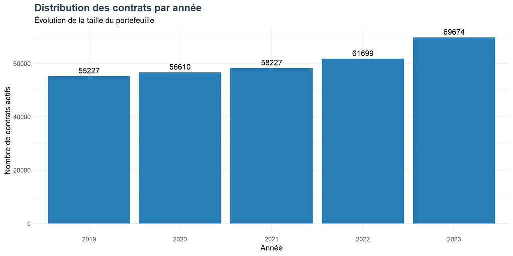

```r
# Distribution des contrats par année
ggplot(df_final, aes(x = factor(idx_year))) +
  geom_bar(fill = "#2980B9") +
  geom_text(stat = 'count', aes(label = ..count..), vjust = -0.5) +
  labs(title = "Distribution des contrats par année",
       subtitle = "Évolution de la taille du portefeuille",
       x = "Année", y = "Nombre de contrats actifs")
```

**Analyse de la tendance des contrats** : Le portefeuille affiche une croissance globale de + 26% sur la période (passant de 55 227 à 69 674 contrats). On distingue deux phases : une progression régulière jusqu’en 2021, suivie d’une accélération marquée en 2023 (+ 13% en un an). Cette dynamique commerciale positive nécessite une surveillance accrue du risque, les affaires nouvelles présentant souvent une sinistralité plus volatile avec un effet de nouveauté.

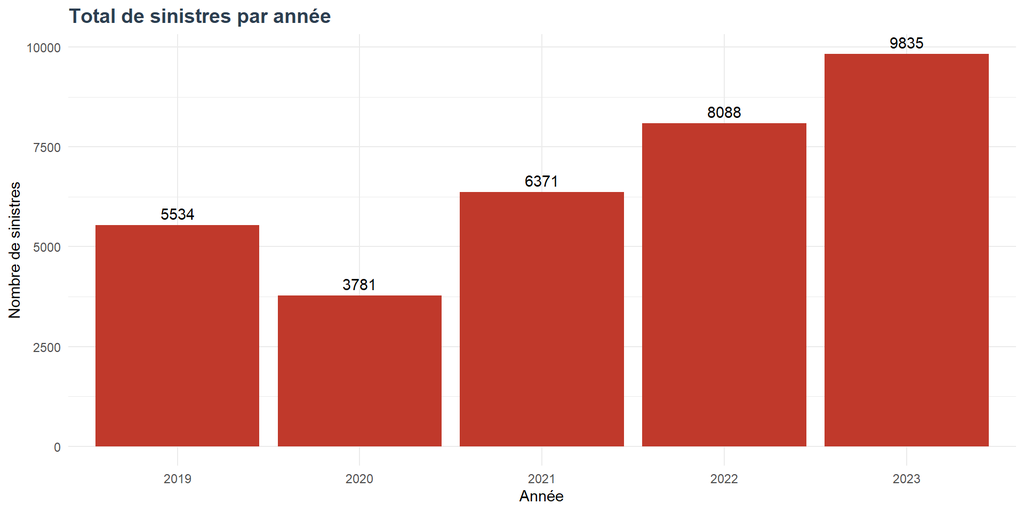

```r
# Histogramme du total de sinistres par année
df_sinistres_annee <- df_final %>%
  group_by(idx_year) %>%
  summarise(total_sinistres = sum(nb_sinistres_total))

ggplot(df_sinistres_annee, aes(x = factor(idx_year), y = total_sinistres)) +
  geom_col(fill = "#C0392B") +
  geom_text(aes(label = total_sinistres), vjust = -0.5) +
  labs(title = "Total de sinistres par année",
       x = "Année", y = "Nombre de sinistres")
```

**Analyse de la tendance des sinistres** : L’année 2020 marque un point très bas avec 3 781 sinistres, dû à la baisse du trafic lors de la crise sanitaire. Cependant, la dynamique s’inverse par la suite. En 2023, on observe une hausse des sinistres de + 21,6%, alors que le portefeuille n’a crû que de + 13%. Les sinistres augmentent beaucoup plus vite que le nombre de nouveaux clients. Cela signifie que la fréquence des accidents augmente.

# 3. Analyse du parc véhicule

Comprendre ce que nous assurons permet de mieux anticiper les coûts de réparation.

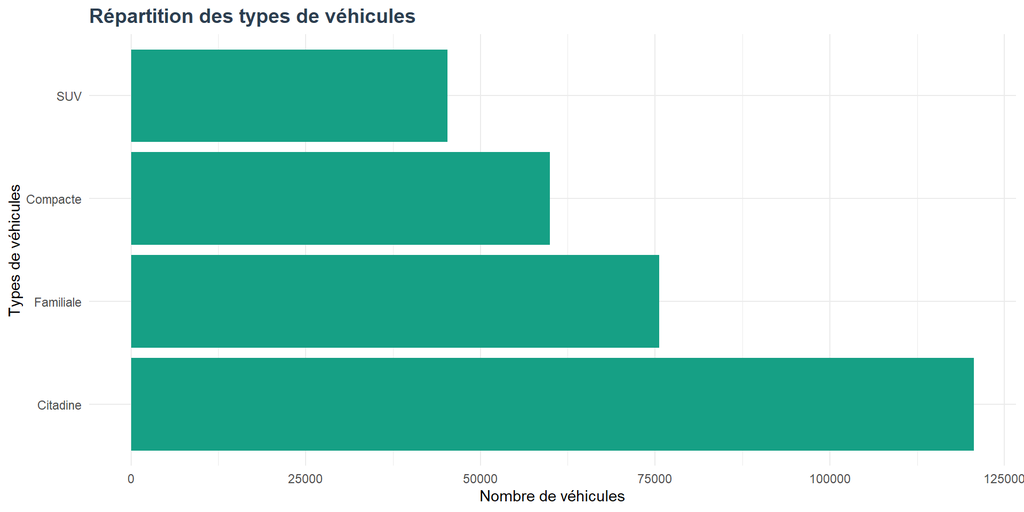

```r
# Répartition par type de véhicule
ggplot(df_final, aes(x = fct_infreq(vh_segment))) +
  geom_bar(fill = "#16A085") +
  coord_flip() +
  labs(title = "Répartition des types de véhicules",
       x = "Types de véhicules", y = "Nombre de véhicules")
```

**Analyse de la répartition par type de véhicule** : Le parc assuré est dominé par les Citadines (~120k véhicules), suivies des Familiales et des Compactes. Les SUV représentent la part la plus faible du portefeuille. Cette répartition est un avantage : les citadines coûtent généralement moins cher à réparer en cas d’accident que les gros véhicules, ce qui limite nos dépenses.

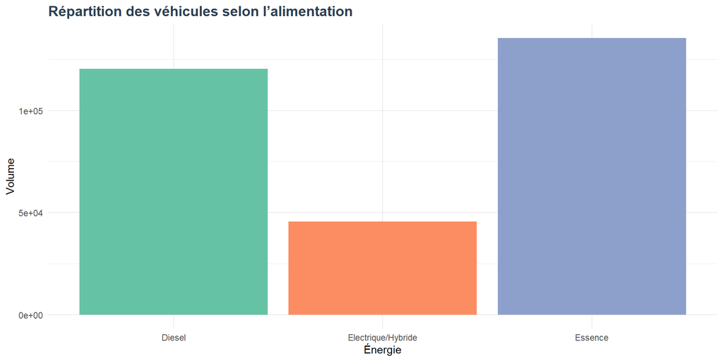

```r
# Répartition des véhicules selon l’alimentation (essence, diesel, électrique…)
ggplot(df_final, aes(x = vh_energy, fill = vh_energy)) +
  geom_bar() +
  scale_fill_brewer(palette = "Set2") +
  labs(title = "Répartition des véhicules selon l’alimentation",
       x = "Énergie", y = "Volume") +
  theme(legend.position = "none")
```